# Проект 2. Разведывательный анализ данных

Вас пригласили поучаствовать в одном из проектов UNICEF — международного подразделения ООН, чья миссия состоит в повышении уровня благополучия детей по всему миру.

Суть проекта — отследить влияние условий жизни учащихся в возрасте от 15 до 22 лет на их успеваемость по математике, чтобы на ранней стадии выявлять студентов, находящихся в группе риска.

И сделать это можно с помощью модели, которая предсказывала бы результаты госэкзамена по математике для каждого ученика школы (вот она, сила ML!). Чтобы определиться с параметрами будущей модели, проведите разведывательный анализ данных и составьте отчёт по его результатам.

Посмотрим на переменные, которые содержит датасет:

- 1 school — аббревиатура школы, в которой учится ученик
- 2 sex — пол ученика ('F' - женский, 'M' - мужской)
- 3 age — возраст ученика (от 15 до 22)
- 4 address — тип адреса ученика ('U' - городской, 'R' - за городом)
- 5 famsize — размер семьи('LE3' <= 3, 'GT3' >3)
- 6 Pstatus — статус совместного жилья родителей ('T' - живут вместе 'A' - раздельно)
- 7 Medu — образование матери (0 - нет, 1 - 4 класса, 2 - 5-9 классы, 3 - среднее специальное или 11 классов, 4 - высшее)
- 8 Fedu — образование отца (0 - нет, 1 - 4 класса, 2 - 5-9 классы, 3 - среднее специальное или 11 классов, 4 - высшее)
- 9 Mjob — работа матери ('teacher' - учитель, 'health' - сфера здравоохранения, 'services' - гос служба, 'at_home' не работает, 'other' - другое)
- 10 Fjob — работа отца ('teacher' - учитель, 'health' - сфера здравоохранения, 'services' - гос служба, 'at_home' не работает, 'other' - другое)
- 11 reason — причина выбора школы ('home' - близость к дому, 'reputation' - репутация школы, 'course' - образовательная программа, 'other' - другое)
- 12 guardian — опекун ('mother' - мать, 'father' - отец, 'other' - другое)
- 13 traveltime — время в пути до школы (1 - <15 мин., 2 - 15-30 мин., 3 - 30-60 мин., 4 - >60 мин.)
- 14 studytime — время на учёбу помимо школы в неделю (1 - <2 часов, 2 - 2-5 часов, 3 - 5-10 часов, 4 - >10 часов)
- 15 failures — количество внеучебных неудач (n, если 1<=n<=3, иначе 0)
- 16 schoolsup — дополнительная образовательная поддержка (yes или no)
- 17 famsup — семейная образовательная поддержка (yes или no)
- 18 paid — дополнительные платные занятия по математике (yes или no)
- 19 activities — дополнительные внеучебные занятия (yes или no)
- 20 nursery — посещал детский сад (yes или no)
- 21 higher — хочет получить высшее образование (yes или no)
- 22 internet — наличие интернета дома (yes или no)
- 23 romantic — в романтических отношениях (yes или no)
- 24 famrel — семейные отношения (от 1 - очень плохо до 5 - очень хорошо)
- 25 freetime — свободное время после школы (от 1 - очень мало до 5 - очень мого)
- 26 goout — проведение времени с друзьями (от 1 - очень мало до 5 - очень много)
- 27 health — текущее состояние здоровья (от 1 - очень плохо до 5 - очень хорошо)
- 28 absences — количество пропущенных занятий
- 29 score — баллы по госэкзамену по математике

```python
import pandas as pd
import matplotlib.pyplot as plt
import seaborn as sns
from itertools import combinations
from scipy.stats import ttest_ind
import numpy as np
```

```python
pd.set_option('display.max_rows', 50)  # показывать больше строк
pd.set_option('display.max_columns', 50)  # показывать больше колонок

stud = pd.read_csv('stud_math.csv')
```

### Рекомендации по выполнению

- Проведите первичную обработку данных. Так как данных много, стоит написать функции, которые можно применять к столбцам определённого типа.
- Посмотрите на распределение признака для числовых переменных, устраните выбросы.
- Оцените количество уникальных значений для номинативных переменных.
- По необходимости преобразуйте данные
- Проведите корреляционный анализ количественных переменных
- Отберите не коррелирующие переменные.
- Проанализируйте номинативные переменные и устраните те, которые не влияют на предсказываемую величину (в нашем случае — на переменную score).
- Не забудьте сформулировать выводы относительно качества данных и тех переменных, которые вы будете использовать в дальнейшем построении модели

### Критерии

- Качество кода и соответствие стандартам оформления pep-8.
- Для каждого столбца найдено количество пустых строк, найдены и убраны выбросы.
- Для количественных переменных построены гистограммы распределений и сделаны выводы.
- Проведён корреляционный анализ и анализ номинативных переменных, корректно отобраны переменные для построения модели.
- Сформулированы промежуточные и итоговые выводы.

# Первичная обработка данных

### 1. Датасет

```python
stud.head(5)
```

|  | school | sex | age | address | famsize | Pstatus | Medu | Fedu | Mjob | Fjob | reason | guardian | traveltime | studytime | failures | schoolsup | famsup | paid | activities | nursery | studytime, granular | higher | internet | romantic | famrel | freetime | goout | health | absences | … |
| --- | --- | --- | --- | --- | --- | --- | --- | --- | --- | --- | --- | --- | --- | --- | --- | --- | --- | --- | --- | --- | --- | --- | --- | --- | --- | --- | --- | --- | --- | --- |
| 0 | GP | F | 18 | U | NaN | A | 4.0 | 4.0 | at_home | teacher | course | mother | 2.0 | 2.0 | 0.0 | yes | no | no | no | yes | -6.0 | yes | NaN | no | 4.0 | 3.0 | 4.0 | 3.0 | 6.0 | … |
| 1 | GP | F | 17 | U | GT3 | NaN | 1.0 | 1.0 | at_home | other | course | father | 1.0 | 2.0 | 0.0 | no | yes | no | no | no | -6.0 | yes | yes | no | 5.0 | 3.0 | 3.0 | 3.0 | 4.0 | … |
| 2 | GP | F | 15 | U | LE3 | T | 1.0 | 1.0 | at_home | other | other | mother | 1.0 | 2.0 | 3.0 | yes | no | NaN | no | yes | -6.0 | yes | yes | NaN | 4.0 | 3.0 | 2.0 | 3.0 | 10.0 | … |
| 3 | GP | F | 15 | U | GT3 | T | 4.0 | 2.0 | health | NaN | home | mother | 1.0 | 3.0 | 0.0 | no | yes | yes | yes | yes | -9.0 | yes | yes | yes | 3.0 | 2.0 | 2.0 | 5.0 | 2.0 | … |
| 4 | GP | F | 16 | U | GT3 | T | 3.0 | 3.0 | other | other | home | father | 1.0 | 2.0 | 0.0 | no | yes | yes | no | yes | -6.0 | yes | no | no | 4.0 | 3.0 | 2.0 | 5.0 | 4.0 | … |

```python
stud.info()
```

```
<class 'pandas.core.frame.DataFrame'>
RangeIndex: 395 entries, 0 to 394
Data columns (total 30 columns):
 #   Column               Non-Null Count  Dtype
---  ------               --------------  -----
 0   school               395 non-null    object
 1   sex                  395 non-null    object
 2   age                  395 non-null    int64
 3   address              378 non-null    object
 4   famsize              368 non-null    object
 5   Pstatus              350 non-null    object
 6   Medu                 392 non-null    float64
 7   Fedu                 371 non-null    float64
 8   Mjob                 376 non-null    object
 9   Fjob                 359 non-null    object
```

[output cut: 22 more lines]

*Сколько в датасете числовых столбцов?* 13 числовых столбцов

*Сколько в датасете строковых столбцов?* 17 строковых столбцов

- Датасет состоит из данных о 395 учениках, в датасете 30 колонок.
- 1 колонка не присутствует в описании датасета: *studytime, granular*
- Во всех столбцах, кроме *school, sex, age* присутствуют пустые значения.

Посмотрим точное количество пропущенных данных в каждом столбце.

```python
stud.drop('studytime, granular', axis = 1, inplace = True)
```

```python
'''
Такой вывод помогает лучше понять картину происходящего в данных.
Самый простой способ борьбы с пропущенными значениями - это их удаление.
Нам может казаться, что так как пропусков достаточно мало, то это не повлияет на картину.
Однако, если удалить все строки с пропусками, датасет может сократиться до 90 значений.
'''

nan_stud = pd.DataFrame(stud.isna().sum(), columns=['NaN'])
nan_stud
```

|  | NaN |
| --- | --- |
| school | 0 |
| sex | 0 |
| age | 0 |
| address | 17 |
| famsize | 27 |
| Pstatus | 45 |
| Medu | 3 |
| Fedu | 24 |
| Mjob | 19 |
| Fjob | 36 |
| reason | 17 |
| guardian | 31 |
| traveltime | 28 |
| studytime | 7 |
| failures | 22 |
| schoolsup | 9 |
| famsup | 39 |
| paid | 40 |
| activities | 14 |
| nursery | 16 |
| higher | 20 |
| internet | 34 |
| romantic | 31 |
| famrel | 27 |
| freetime | 11 |
| goout | 8 |
| health | 15 |
| absences | 12 |
| score | 6 |

### 2. Анализ данных на предмет пропущенных значений, выбросов и построение гистограмм распределений.

- Вы можете по-разному рассматривать ваши данные (относить одно к числовым/строковым значениям)
- Мы сейчас ориентируемся на авторское решение
- Авторское решение повторяет пример обработки датасета в вашем юните

```python
def first_look(col, boundaries=None):
    print('Столбец', col)
    print('Распределение признака:')
    fig, ax = plt.subplots()
    '''Проверка на строковый тип данных'''
    # stud.loc[:, col] - функция вывода колонки
    if stud.loc[:, col].dtypes == np.dtype('O'):
        sns.countplot(stud.loc[:, col], ax=ax)
        plt.show()
    else:
        stud.loc[:, col].hist(ax=ax)
        ax.set_xlabel(col)
        ax.set_ylabel('count')
        plt.show()
        if boundaries is not None:  # Проверка на наличие выбросов по информации из датасета
            if stud.loc[(~stud.loc[:, col].between(boundaries[0], boundaries[1])) &
                        pd.notnull(stud.loc[:, col])].shape[0] > 0:
                print('Найдены выбросы:')
                display(stud.loc[(~stud.loc[:, col].between(boundaries[0], boundaries[1])) &
                                 pd.notnull(stud.loc[:, col])])

    print()
```

```
Столбец school
Распределение признака:
```

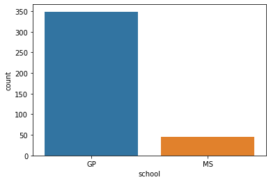

```
Столбец sex
Распределение признака:
```

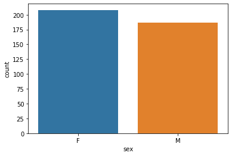

```
Столбец age
Распределение признака:
```

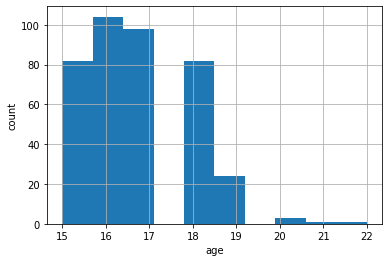

```
Столбец address
Распределение признака:
```

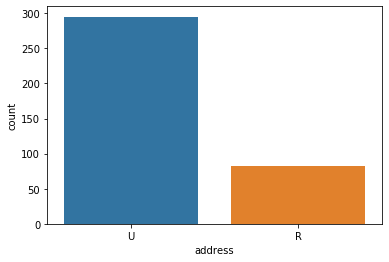

```
Столбец famsize
Распределение признака:
```

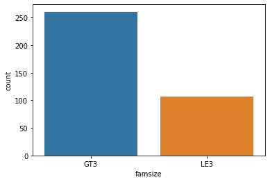

```
Столбец Pstatus
Распределение признака:
```

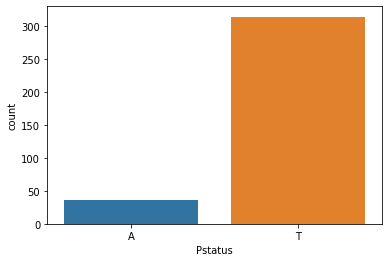

```
Столбец Medu
Распределение признака:
```

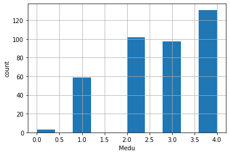

```
Столбец Fedu
Распределение признака:
```

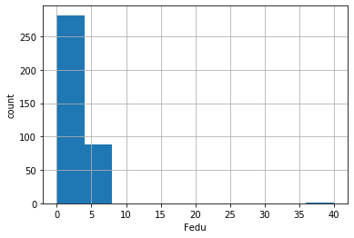

```
Найдены выбросы:
```

|  | school | sex | age | address | famsize | Pstatus | Medu | Fedu | Mjob | Fjob | reason | guardian | traveltime | studytime | failures | schoolsup | famsup | paid | activities | nursery | higher | internet | romantic | famrel | freetime | goout | health | absences | score |
| --- | --- | --- | --- | --- | --- | --- | --- | --- | --- | --- | --- | --- | --- | --- | --- | --- | --- | --- | --- | --- | --- | --- | --- | --- | --- | --- | --- | --- | --- |
| 11 | GP | F | 15 | U | GT3 | NaN | 2.0 | 40.0 | services | other | reputation | father | 3.0 | 3.0 | 0.0 | no | yes | no | yes | yes | yes | yes | no | 5.0 | 2.0 | 2.0 | 4.0 | 4.0 | 60.0 |

```
Столбец Mjob
Распределение признака:
```

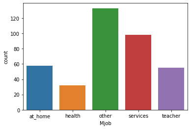

```
Столбец Fjob
Распределение признака:
```

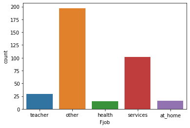

```
Столбец reason
Распределение признака:
```

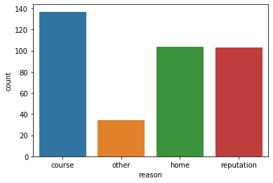

```
Столбец guardian
Распределение признака:
```

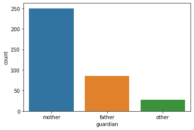

```
Столбец traveltime
Распределение признака:
```

[17 more figures not shown]

```python
first_look('school')
first_look('sex')
first_look('age', boundaries=(15, 22))
first_look('address')
first_look('famsize')
first_look('Pstatus')
first_look('Medu', boundaries=(0,4))
first_look('Fedu', boundaries=(0,4))
first_look('Mjob')
first_look('Fjob')
first_look('reason')
first_look('guardian')
first_look('traveltime', boundaries=(1,4))
first_look('studytime', boundaries=(1,4))
first_look('failures', boundaries=(0,4))
first_look('schoolsup')
first_look('famsup')
first_look('paid')
first_look('activities')
first_look('nursery')
first_look('higher')
first_look('internet')
first_look('romantic')
first_look('famrel', boundaries=(1,5))
first_look('freetime', boundaries=(1,5))
first_look('goout', boundaries=(1,5))
first_look('health', boundaries=(1,5))
first_look('absences')
first_look('score', boundaries=(0, 100))
```

#### Разбираемся с выбросами в колонках

- Fedu
- famrel
- absences

```python
stud['Fedu'] = np.where(stud['Fedu'] == 40, 4, stud['Fedu'])
```

```python
stud['famrel'] = np.where(stud['famrel'] == -1.0, 1, stud['famrel'])
```

```
Столбец Fedu
Распределение признака:
```

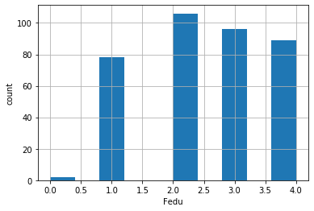

```
Столбец famrel
Распределение признака:
```

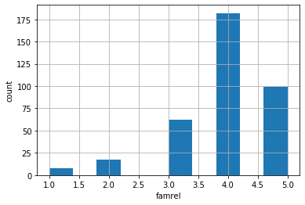

```python
first_look('Fedu', boundaries=(0,4))
first_look('famrel', boundaries=(1,5))
```

```python
len(stud)
```

```
395
```

Столбец *absences*:

```
Столбец absences
Распределение признака:
```

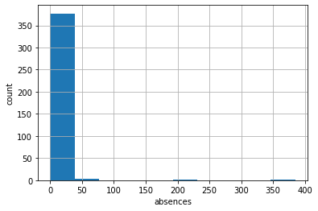

```python
first_look('absences')
```

```python
stud.loc[stud.absences > 190]
```

|  | school | sex | age | address | famsize | Pstatus | Medu | Fedu | Mjob | Fjob | reason | guardian | traveltime | studytime | failures | schoolsup | famsup | paid | activities | nursery | higher | internet | romantic | famrel | freetime | goout | health | absences | score |
| --- | --- | --- | --- | --- | --- | --- | --- | --- | --- | --- | --- | --- | --- | --- | --- | --- | --- | --- | --- | --- | --- | --- | --- | --- | --- | --- | --- | --- | --- |
| 222 | GP | F | 16 | U | GT3 | T | 2.0 | 3.0 | services | teacher | other | mother | 1.0 | 2.0 | 0.0 | yes | NaN | no | no | yes | yes | yes | no | 2.0 | 3.0 | 1.0 | 3.0 | 385.0 | 85.0 |
| 390 | MS | M | 20 | U | LE3 | A | 2.0 | 2.0 | services | services | course | NaN | 1.0 | 2.0 | 2.0 | no | yes | yes | no | yes | yes | no | no | 5.0 | 5.0 | 4.0 | 4.0 | 212.0 | 45.0 |

```python
stud = stud.loc[~stud['absences'].isin([385.0, 212.0])]
```

```python
stud.loc[stud.absences > 190]
```

|  | school | sex | age | address | famsize | Pstatus | Medu | Fedu | Mjob | Fjob | reason | guardian | traveltime | studytime | failures | schoolsup | famsup | paid | activities | nursery | higher | internet | romantic | famrel | freetime | goout | health | absences | score |
| --- | --- | --- | --- | --- | --- | --- | --- | --- | --- | --- | --- | --- | --- | --- | --- | --- | --- | --- | --- | --- | --- | --- | --- | --- | --- | --- | --- | --- | --- |

```python
len(stud)
```

```
393
```

*Формула интерквартильного расстояния*

Выбросом считаются такие значения, которые лежат вне рамок

percentile(25) -1.5*IQR : percentile(75)+1.5*IQR,

где IQR = percentile(75) - percentile(25)

```python
percentile25 = stud.absences.quantile(0.25)
percentile75 = stud.absences.quantile(0.75)
IQR = percentile75 - percentile25

print('25-й перцентиль: {},'.format(percentile25),
      '75-й перцентиль: {},'.format(percentile75),
      "IQR: {}, ".format(IQR),
      "Границы выбросов: [{f}, {l}].".format(f = 0, l=percentile75 + 1.5*IQR))
```

```
25-й перцентиль: 0.0, 75-й перцентиль: 8.0, IQR: 8.0,  Границы выбросов: [0, 20.0].
```

```python
stud.loc[~stud.absences.between(percentile25 - 1.5*IQR, percentile75 + 1.5*IQR), 'absences']
```

```
24      NaN
40     25.0
74     54.0
101     NaN
103    26.0
120     NaN
129     NaN
150     NaN
172     NaN
183    56.0
198    24.0
205    28.0
215     NaN
216    22.0
227     NaN
254     NaN
260    21.0
265     NaN
270     NaN
276    75.0
277    22.0
280    30.0
307    38.0
313    22.0
315    40.0
320    23.0
352     NaN
Name: absences, dtype: float64
```

```python
stud = stud.loc[stud.absences.between(percentile25 - 1.5*IQR, 30)|pd.isnull(stud.absences)]
```

```python
len(stud)
```

```
388
```

```
Столбец absences
Распределение признака:
```

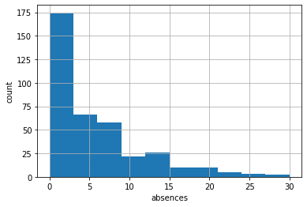

```
Пропущенных значений: 12
```

```python
first_look('absences')
print('Пропущенных значений:', stud.absences.isna().sum())
```

#### Работа с пропущенными значениями

Работа с пропусками не предусматривается в критериях к этой работе.

- удаление данных
- замена на среднее значение/медиану
- замена исходя из здравого смысла (то, что мы делали для данных с выбросами)

# Корреляционный анализ

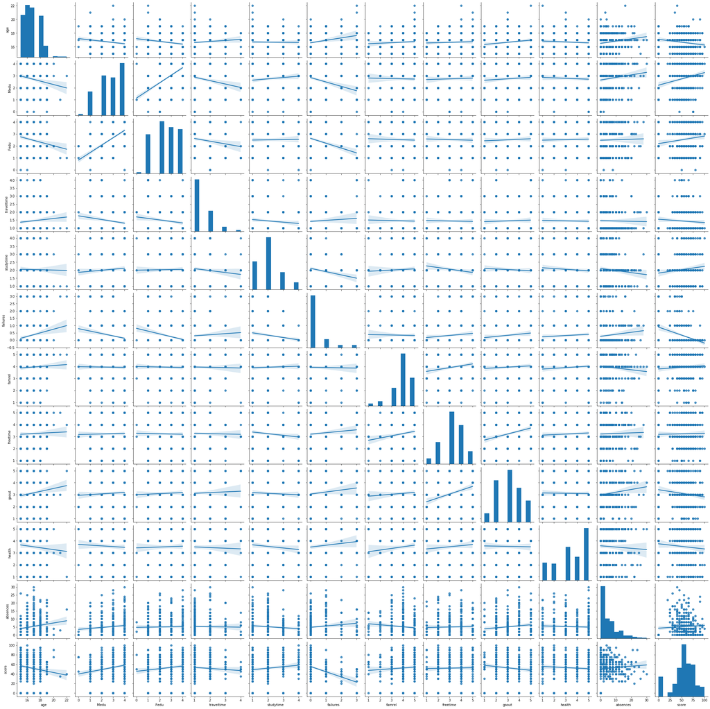

```python
sns.pairplot(stud, kind = 'reg')
```

```python
stud.corr()
```

|  | age | Medu | Fedu | traveltime | studytime | failures | famrel | freetime | goout | health | absences | score |
| --- | --- | --- | --- | --- | --- | --- | --- | --- | --- | --- | --- | --- |
| age | 1.000000 | -0.164411 | -0.171007 | 0.083477 | -0.015139 | 0.210278 | 0.056311 | 0.036088 | 0.137394 | -0.070700 | 0.150931 | -0.151888 |
| Medu | -0.164411 | 1.000000 | 0.626778 | -0.180902 | 0.084800 | -0.245947 | -0.017382 | 0.026806 | 0.060211 | -0.047575 | 0.113094 | 0.219206 |
| Fedu | -0.171007 | 0.626778 | 1.000000 | -0.146271 | 0.016255 | -0.277594 | -0.024039 | -0.022947 | 0.042702 | 0.026564 | 0.021333 | 0.131798 |
| traveltime | 0.083477 | -0.180902 | -0.146271 | 1.000000 | -0.098532 | 0.068036 | -0.021419 | -0.018359 | 0.036489 | -0.027030 | -0.016983 | -0.067802 |
| studytime | -0.015139 | 0.084800 | 0.016255 | -0.098532 | 1.000000 | -0.181211 | 0.040179 | -0.118587 | -0.046808 | -0.078640 | -0.090338 | 0.114569 |
| failures | 0.210278 | -0.245947 | -0.277594 | 0.068036 | -0.181211 | 1.000000 | -0.018681 | 0.092760 | 0.114145 | 0.080700 | 0.107234 | -0.345554 |
| famrel | 0.056311 | -0.017382 | -0.024039 | -0.021419 | 0.040179 | -0.018681 | 1.000000 | 0.170535 | 0.064759 | 0.090267 | -0.097115 | 0.067560 |
| freetime | 0.036088 | 0.026806 | -0.022947 | -0.018359 | -0.118587 | 0.092760 | 0.170535 | 1.000000 | 0.283154 | 0.064524 | 0.026601 | 0.020049 |
| goout | 0.137394 | 0.060211 | 0.042702 | 0.036489 | -0.046808 | 0.114145 | 0.064759 | 0.283154 | 1.000000 | -0.015206 | 0.120282 | -0.124221 |
| health | -0.070700 | -0.047575 | 0.026564 | -0.027030 | -0.078640 | 0.080700 | 0.090267 | 0.064524 | -0.015206 | 1.000000 | -0.044616 | -0.070991 |
| absences | 0.150931 | 0.113094 | 0.021333 | -0.016983 | -0.090338 | 0.107234 | -0.097115 | 0.026601 | 0.120282 | -0.044616 | 1.000000 | 0.068886 |
| score | -0.151888 | 0.219206 | 0.131798 | -0.067802 | 0.114569 | -0.345554 | 0.067560 | 0.020049 | -0.124221 | -0.070991 | 0.068886 | 1.000000 |

```python
cmap = cmap=sns.diverging_palette(5, 250, as_cmap=True)

def magnify():
    return [dict(selector="th",
                 props=[("font-size", "7pt")]),
            dict(selector="td",
                 props=[('padding', "0em 0em")]),
            dict(selector="th:hover",
                 props=[("font-size", "12pt")]),
            dict(selector="tr:hover td:hover",
                 props=[('max-width', '200px'),
                        ('font-size', '12pt')])
]

stud.corr().style.background_gradient(cmap, axis=1)\
    .set_properties(**{'max-width': '80px', 'font-size': '10pt'})\
    .set_caption("Hover to magify")\
    .set_precision(2)\
    .set_table_styles(magnify())
```

Hover to magify

|  | age | Medu | Fedu | traveltime | studytime | failures | famrel | freetime | goout | health | absences | score |
| --- | --- | --- | --- | --- | --- | --- | --- | --- | --- | --- | --- | --- |
| age | 1.00 | -0.16 | -0.17 | 0.08 | -0.02 | 0.21 | 0.06 | 0.04 | 0.14 | -0.07 | 0.15 | -0.15 |
| Medu | -0.16 | 1.00 | 0.63 | -0.18 | 0.08 | -0.25 | -0.02 | 0.03 | 0.06 | -0.05 | 0.11 | 0.22 |
| Fedu | -0.17 | 0.63 | 1.00 | -0.15 | 0.02 | -0.28 | -0.02 | -0.02 | 0.04 | 0.03 | 0.02 | 0.13 |
| traveltime | 0.08 | -0.18 | -0.15 | 1.00 | -0.10 | 0.07 | -0.02 | -0.02 | 0.04 | -0.03 | -0.02 | -0.07 |
| studytime | -0.02 | 0.08 | 0.02 | -0.10 | 1.00 | -0.18 | 0.04 | -0.12 | -0.05 | -0.08 | -0.09 | 0.11 |
| failures | 0.21 | -0.25 | -0.28 | 0.07 | -0.18 | 1.00 | -0.02 | 0.09 | 0.11 | 0.08 | 0.11 | -0.35 |
| famrel | 0.06 | -0.02 | -0.02 | -0.02 | 0.04 | -0.02 | 1.00 | 0.17 | 0.06 | 0.09 | -0.10 | 0.07 |
| freetime | 0.04 | 0.03 | -0.02 | -0.02 | -0.12 | 0.09 | 0.17 | 1.00 | 0.28 | 0.06 | 0.03 | 0.02 |
| goout | 0.14 | 0.06 | 0.04 | 0.04 | -0.05 | 0.11 | 0.06 | 0.28 | 1.00 | -0.02 | 0.12 | -0.12 |
| health | -0.07 | -0.05 | 0.03 | -0.03 | -0.08 | 0.08 | 0.09 | 0.06 | -0.02 | 1.00 | -0.04 | -0.07 |
| absences | 0.15 | 0.11 | 0.02 | -0.02 | -0.09 | 0.11 | -0.10 | 0.03 | 0.12 | -0.04 | 1.00 | 0.07 |
| score | -0.15 | 0.22 | 0.13 | -0.07 | 0.11 | -0.35 | 0.07 | 0.02 | -0.12 | -0.07 | 0.07 | 1.00 |

*Какие столбцы мы можем выделить, как коррелирующие со столбцом score?*

- age
- Medu
- Fedu
- studytime
- failures
- goout

# Анализ номинативных переменных

```python
def nominative_analysis(col):
    if stud.loc[:, col].dtypes == np.dtype('O'): # Проверка на строковый тип данных
        print('Столбец', col)
        print('Распределение баллов по значениям признака:')
        fig, ax = plt.subplots(figsize = (14, 4))
        sns.boxplot(x=col, y='score',
                    data=stud,
                   ax=ax)
        plt.xticks(rotation=45)
        ax.set_title('Boxplot for ' + col)
        plt.show()
        permutations_all = list(combinations(stud.loc[:, col].dropna().unique(), 2))
        for perm in permutations_all:
            if ttest_ind(stud.loc[stud.loc[:, col] == perm[0], 'score'].dropna(),
                            stud.loc[stud.loc[:, col] == perm[1], 'score'].dropna()).pvalue \
                <= 0.05/len(permutations_all): # Учли поправку Бонферони
                print('Найдены статистически значимые различия для колонки', col)
                break
        print('----------------------------------')
        print()
```

```
Столбец school
Распределение баллов по значениям признака:
```

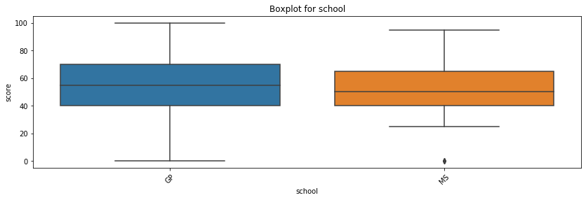

```
----------------------------------

Столбец sex
Распределение баллов по значениям признака:
```

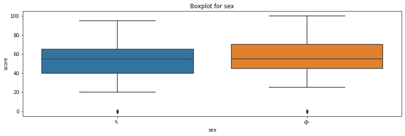

```
Найдены статистически значимые различия для колонки sex
----------------------------------

Столбец address
Распределение баллов по значениям признака:
```

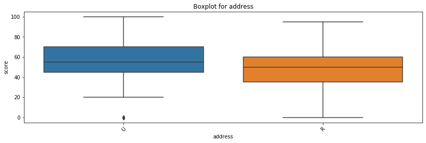

```
Найдены статистически значимые различия для колонки address
----------------------------------

Столбец famsize
Распределение баллов по значениям признака:
```

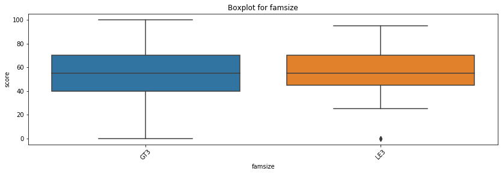

```
----------------------------------

Столбец Pstatus
Распределение баллов по значениям признака:
```

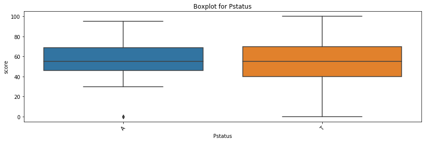

```
----------------------------------

Столбец Mjob
Распределение баллов по значениям признака:
```

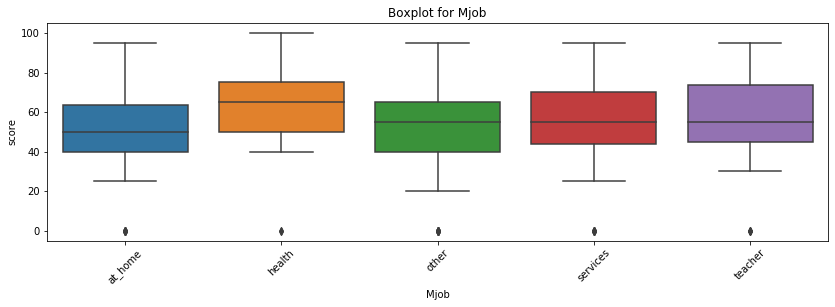

```
Найдены статистически значимые различия для колонки Mjob
----------------------------------

Столбец Fjob
Распределение баллов по значениям признака:
```

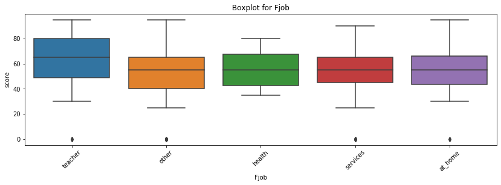

```
----------------------------------

Столбец reason
Распределение баллов по значениям признака:
```

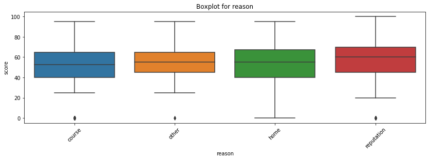

```
----------------------------------

Столбец guardian
Распределение баллов по значениям признака:
```

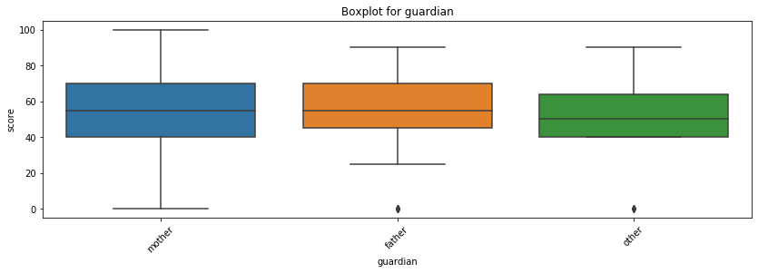

```
----------------------------------

Столбец schoolsup
Распределение баллов по значениям признака:
```

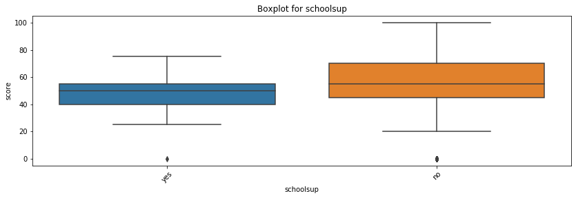

```
Найдены статистически значимые различия для колонки schoolsup
----------------------------------

Столбец famsup
Распределение баллов по значениям признака:
```

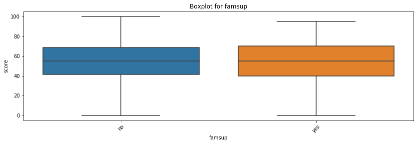

```
----------------------------------

Столбец paid
Распределение баллов по значениям признака:
```

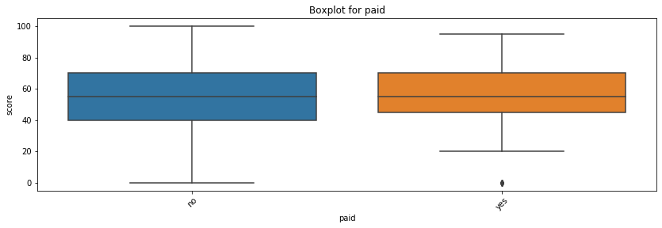

```
----------------------------------

Столбец activities
Распределение баллов по значениям признака:
```

[5 more figures not shown]

```
Найдены статистически значимые различия для колонки romantic
----------------------------------
```

```python
for col in stud.columns:
    nominative_analysis(col)
```

```python
stud.drop(['school', 'famsize', 'Pstatus', 'Fjob', 'reason', 'guardian', 'famsup', 'activities',
          'nursery', 'internet'], axis = 1, inplace = True)
```

```python
stud.head()
```

|  | sex | age | address | Medu | Fedu | Mjob | traveltime | studytime | failures | schoolsup | paid | higher | romantic | famrel | freetime | goout | health | absences | score |
| --- | --- | --- | --- | --- | --- | --- | --- | --- | --- | --- | --- | --- | --- | --- | --- | --- | --- | --- | --- |
| 0 | F | 18 | U | 4.0 | 4.0 | at_home | 2.0 | 2.0 | 0.0 | yes | no | yes | no | 4.0 | 3.0 | 4.0 | 3.0 | 6.0 | 30.0 |
| 1 | F | 17 | U | 1.0 | 1.0 | at_home | 1.0 | 2.0 | 0.0 | no | no | yes | no | 5.0 | 3.0 | 3.0 | 3.0 | 4.0 | 30.0 |
| 2 | F | 15 | U | 1.0 | 1.0 | at_home | 1.0 | 2.0 | 3.0 | yes | NaN | yes | NaN | 4.0 | 3.0 | 2.0 | 3.0 | 10.0 | 50.0 |
| 3 | F | 15 | U | 4.0 | 2.0 | health | 1.0 | 3.0 | 0.0 | no | yes | yes | yes | 3.0 | 2.0 | 2.0 | 5.0 | 2.0 | 75.0 |
| 4 | F | 16 | U | 3.0 | 3.0 | other | 1.0 | 2.0 | 0.0 | no | yes | yes | no | 4.0 | 3.0 | 2.0 | 5.0 | 4.0 | 50.0 |